# Desafio 01 - IGTI

- Autor: Rodrigo de Lima Oliveira
- LinkedIn: https://www.linkedin.com/in/rodrigolima82/

**Pergunta 01:** Qual é a proporção (em %) de valores nulos existente na coluna "temp" (temperatura ambiente normalizada)?

- 15%
- 10%
- 0%
- 5%

**Pergunta 02:** Após retirar as linhas que contém valores nulos para a coluna "dteday", passamos a contar com quantas instancias e atributos, respectivamente?

- (17,15641)
- (15641,17)
- (17,17379)
- (17379,17)

**Pergunta 03:** Utilize os mesmos dados da questão anterior ("hum" e "casual" como variáveis independentes e "cnt" como variavel dependente). Aplique a árvore de decisão como regressão. Qual é o valor aproximado de R2? Utilize as entradas como teste e valores "default".

- 1,00
- 0,30
- 0,70
- 0,40

**Pergunta 04:** Preencha os valores nulos das colunas "hum","cnt" e "casual" com os valores médios. Utilize as variáveis "hum" e "casual" como independentes e a "cnt" como dependente. Aplique uma regressão linear. Qual o valor de R2? Utilize as entradas como teste.

- 0.80
- -0.40
- -0.80
- 0.40

**Pergunta 05:** Considere o dataset após a retirada das linhas que continham valores nulos para a coluna "dteday". Qual é o valor médio para os dados da coluna "temp" (temperatura ambiente normalizada)?

- 0,192
- 0,156
- 1,192
- 0,496

**Pergunta 06:** Considere o dataset após a retirada das linhas que continham valores nulos para a coluna "dteday". Transforme a coluna "dteday" no tipo "datetime". Qual é a última data presente no dataset ( YYYY-MM-DD)?

- 2012-01-31
- 2012-01-31
- 2014-12-31
- 2012-12-31

**Pergunta 07:** Considere o dataset após a retirada das linhas que continham valores nulos para a coluna "dteday". Selecione as colunas "season", "temp", "atemp", "hum", "windspeed". Plot a matriz de correlação. Sobre as variáveis "hum" e "cnt" é CORRETO afirmar:

- Possuem alta correlação linear positiva.
- Possuem baixa correlação linear negativa.
- Possuem alta correlação linear negativa.
- Possuem baixa correlação linear positiva.

**Pergunta 08:** Comparando os valores de R2 encontrado com a regressão linear e com a árvore de decisão, é CORRETO afirmar:

- Os valores encontrados pela árvore de decisão como regressor e a regressão linear são próximos.
- O valor encontrado pela árvore de decisão foi negativo.
- O valor obtido pela árvore de decisão como regressor apresenta maior R2
- O valor encontrado pela regressão linear é superior ao encontrado pela árvore de decisão.

**Pergunta 09:** Com base na árvore de decisão é CORRETO afirmar:

- Pode ser utilizada para classificação e regressão.
- Ávore de Decisão é utilizada apenas para a classificação de dados contínuos.
- Não é possível encontrar os limites de separação entre os conjuntos de dados a partir de uma classificação realizada através da árvore de decisão.
- A análise de regressão com a árvore de decisão só pode ser realizada com valores categóricos.

**Pergunta 10:** Considere o dataset após a retirada das linhas que continham valores nulos para a coluna "dteday". Considerendo o boxplot da variável "windspeed" (velocidade do vento) é CORRETO afirmar?

- Não existem possíveis outliers, pois não existem marcações (pontos) foras dos limites do boxplot.
- Existem possíveis outliers, pois existem marcações (pontos) foras dos limites do boxplot.
- Existem possíveis outliers, pois não existem marcações (pontos) foras dos limites do boxplot.
- Não existem possíveis outliers, pois existem marcações (pontos) foras dos limites do boxplot.

**Pergunta 11:** Considere o dataset após a retirada das linhas que continham valores nulos para a coluna "dteday". Transforme a coluna "season" em valores categóricos. Quantas categorias diferentes existem?

- 3
- 2
- 1
- 4

**Pergunta 12:** No dataset utilizado para o desafio, quantas instâncias e atributos existem, respectivamente?

- (1345,15)
- (17379,17)
- (15,1345)
- (17,17379)

**Pergunta 13:** Considere o dataset após a retirada das linhas que continham valores nulos para a coluna "dteday". Qual é o desvio padrão para os dados da coluna "windspeed" (velocidade do vento normalizada)?

- 0,122
- 0,189
- 0,192
- 1,122

**Pergunta 14:** Quantos tipos diferentes de dados existem no dataset do desafio?

- 2
- 3
- 17
- 12

**Pergunta 15:** Comparando o SVM com a árvore de decisão é CORRETO afirmar:

- SVM e Árvore de Decisão só podem ser utilizados para modelos de classificação.
- Através da Árvore de Decisão não é possível encontrar os limiares de separação entre as classes.
- SVM encontra o hiperplano que gera a maior separação entre os dados.
- Árvore de decisão encontra os hiperplanos de separação do mesmo modo que o SVM.

## Importando bibliotecas

```python
# Importando bibliotecas que serao utilizadas neste projeto
import warnings
warnings.filterwarnings("ignore")

import pandas as pd
import numpy as np
import seaborn as sns
import itertools
import matplotlib.pyplot as plt
%matplotlib inline

from IPython.core.interactiveshell import InteractiveShell
InteractiveShell.ast_node_interactivity = "all"

from sklearn.preprocessing import scale
from sklearn.preprocessing import StandardScaler
from sklearn.preprocessing import MinMaxScaler
```

## Carregando o dataset

```python
# Carregando arquivo csv usando Pandas
train = pd.read_csv("comp_bikes_mod.csv")

# Visualizando o shape do dataset (17.379 linhas x 17 colunas)
print(train.shape)

# Verificando os tipos de dados
train.info()

# Visualizando as primeiras linhas do dataset
train.head()
```

```
(17379, 17)
<class 'pandas.core.frame.DataFrame'>
RangeIndex: 17379 entries, 0 to 17378
Data columns (total 17 columns):
instant       15641 non-null float64
dteday        15641 non-null object
season        15641 non-null float64
yr            15641 non-null float64
mnth          15641 non-null float64
hr            15641 non-null float64
holiday       15641 non-null float64
weekday       15641 non-null float64
workingday    15641 non-null float64
weathersit    15641 non-null float64
temp          15641 non-null float64
atemp         15641 non-null float64
hum           15641 non-null float64
windspeed     15641 non-null float64
casual        15641 non-null float64
registered    15641 non-null float64
cnt           15641 non-null float64
dtypes: float64(16), object(1)
memory usage: 2.3+ MB
```

|  | instant | dteday | season | yr | mnth | hr | holiday | weekday | workingday | weathersit | temp | atemp | hum | windspeed | casual | registered | cnt |
| --- | --- | --- | --- | --- | --- | --- | --- | --- | --- | --- | --- | --- | --- | --- | --- | --- | --- |
| 0 | 1.0 | NaN | 1.0 | 0.0 | 1.0 | 0.0 | 0.0 | 6.0 | 0.0 | 1.0 | NaN | 0.2879 | 0.81 | 0.0 | 3.0 | 13.0 | 16.0 |
| 1 | 2.0 | 2011-01-01 | 1.0 | 0.0 | 1.0 | 1.0 | 0.0 | 6.0 | 0.0 | NaN | 0.22 | 0.2727 | 0.80 | 0.0 | 8.0 | 32.0 | 40.0 |
| 2 | 3.0 | 2011-01-01 | 1.0 | 0.0 | 1.0 | 2.0 | 0.0 | 6.0 | 0.0 | 1.0 | 0.22 | 0.2727 | 0.80 | 0.0 | 5.0 | 27.0 | 32.0 |
| 3 | 4.0 | 2011-01-01 | 1.0 | 0.0 | 1.0 | 3.0 | 0.0 | 6.0 | 0.0 | 1.0 | 0.24 | 0.2879 | 0.75 | 0.0 | 3.0 | 10.0 | 13.0 |
| 4 | 5.0 | 2011-01-01 | 1.0 | 0.0 | 1.0 | 4.0 | 0.0 | 6.0 | NaN | 1.0 | 0.24 | 0.2879 | 0.75 | 0.0 | 0.0 | 1.0 | 1.0 |

## Verificando valores missing

```python
# Funcao para verificar valores missing no dataset
def check_missing(df, display = 10):
    temp_df = df.copy()
    df_nan = (temp_df.isnull().sum() / len(temp_df)) * 100
    missing_data = pd.DataFrame({'Missing n': temp_df.isnull().sum(),'% Missing' :df_nan})
    if missing_data['Missing n'].sum() == 0:
        return print('Ótimo! Não há mais valores faltantes neste dataset.')
    else:
        return missing_data.sort_values('% Missing', ascending = False).head(display)

# Verificando as colunas com dados missing do dataset
check_missing(train, display = 17)
```

|  | Missing n | % Missing |
| --- | --- | --- |
| instant | 1738 | 10.000575 |
| weathersit | 1738 | 10.000575 |
| registered | 1738 | 10.000575 |
| casual | 1738 | 10.000575 |
| windspeed | 1738 | 10.000575 |
| hum | 1738 | 10.000575 |
| atemp | 1738 | 10.000575 |
| temp | 1738 | 10.000575 |
| workingday | 1738 | 10.000575 |
| dteday | 1738 | 10.000575 |
| weekday | 1738 | 10.000575 |
| holiday | 1738 | 10.000575 |
| hr | 1738 | 10.000575 |
| mnth | 1738 | 10.000575 |
| yr | 1738 | 10.000575 |
| season | 1738 | 10.000575 |
| cnt | 1738 | 10.000575 |

## Removendo valores NA da coluna dteday

```python
train = train.dropna(subset=['dteday'])
train.shape
```

```
(15641, 17)
```

## Modelo Decision Tree Regressor

```python
# Fazendo previsões com o Modelo Decision Tree Regressor (Versao 01)

# Import dos módulos
from sklearn.tree import DecisionTreeRegressor
from sklearn.metrics import r2_score

# Criando um novo dataset somente com as colunas para a pergunta
new_train = train[['hum','casual','cnt']]

# Removendo os valores missing
new_train.fillna(new_train.mean(), inplace=True)

# Verificando as colunas com dados missing do dataset
check_missing(new_train, display = 3)

# Verificando o tamanho do dataset
new_train.shape

# Separando as features independentes e dependente (target)
X = new_train[['hum','casual']]
y = new_train['cnt']

# Criando o modelo de arvore de decisão
dt_model = DecisionTreeRegressor()

# Fit do modelo
dt_model.fit(X, y)

# Previsões
y_pred = dt_model.predict(X)

# Avaliando as previsões
accuracy = r2_score(y, y_pred)
print("Score R2: %0.2f" % accuracy)
```

```
Ótimo! Não há mais valores faltantes neste dataset.
```

```
(15641, 3)
```

```
DecisionTreeRegressor(ccp_alpha=0.0, criterion='mse', max_depth=None,
                      max_features=None, max_leaf_nodes=None,
                      min_impurity_decrease=0.0, min_impurity_split=None,
                      min_samples_leaf=1, min_samples_split=2,
                      min_weight_fraction_leaf=0.0, presort='deprecated',
                      random_state=None, splitter='best')
```

```
Score R2: 0.71
```

## Modelo Linear Regression

```python
# Fazendo previsões com o Modelo Linear Regression

# Import dos módulos
from sklearn.linear_model import LinearRegression
from sklearn.metrics import r2_score

# Criando um novo dataset somente com as colunas para a pergunta
new_train = train[['hum','casual','cnt']]

# Preenchendo os valores missing com a media de cada uma das colunas
new_train.fillna(new_train.mean(), inplace=True)

# Verificando as colunas com dados missing do dataset
check_missing(new_train, display = 3)

# Verificando o tamanho do dataset
new_train.shape

# Separando as features independentes e dependente (target)
X = new_train[['hum','casual']]
y = new_train['cnt']

# Criando o modelo de regressão linear
lr_model = LinearRegression()

# Fit do modelo
lr_model.fit(X, y)

# Previsões
y_pred = lr_model.predict(X)

# Avaliando as previsões
accuracy = r2_score(y, y_pred)
print("Score R2: %0.2f" % accuracy)
```

```
Ótimo! Não há mais valores faltantes neste dataset.
```

```
(15641, 3)
```

```
LinearRegression(copy_X=True, fit_intercept=True, n_jobs=None, normalize=False)
```

```
Score R2: 0.41
```

## Modelo SVM Regressor

```python
# Fazendo previsões com o Modelo SVM Regressor

# Import dos módulos
from sklearn.svm import SVR
from sklearn.metrics import r2_score

# Criando um novo dataset somente com as colunas para a pergunta
new_train = train[['hum','casual','cnt']]

# Preenchendo os valores missing com a media de cada uma das colunas
new_train.fillna(new_train.mean(), inplace=True)

# Verificando as colunas com dados missing do dataset
check_missing(new_train, display = 3)

# Verificando o tamanho do dataset
new_train.shape

# Separando as features independentes e dependente (target)
X = new_train[['hum','casual']]
y = new_train['cnt']

# Criando o modelo SVM
svm_model = SVR(kernel='rbf')

# Fit do modelo
svm_model.fit(X, y)

# Previsões
y_pred = svm_model.predict(X)

# Avaliando as previsões
accuracy = r2_score(y, y_pred)
print("Score R2: %0.2f" % accuracy)
```

```
Ótimo! Não há mais valores faltantes neste dataset.
```

```
(15641, 3)
```

```
SVR(C=1.0, cache_size=200, coef0=0.0, degree=3, epsilon=0.1, gamma='scale',
    kernel='rbf', max_iter=-1, shrinking=True, tol=0.001, verbose=False)
```

```
Score R2: 0.40
```

## Verificando dados estatísticos da feature 'temp'

```python
# Verificando dados estatisticos somente da variavel 'temp'
train['temp'].describe()
```

```
count    14066.000000
mean         0.496926
std          0.192971
min          0.020000
25%          0.340000
50%          0.500000
75%          0.660000
max          1.000000
Name: temp, dtype: float64
```

## Transformando a variavel dteday para o formato datetime

```python
# Transformando a coluna data
train['dteday'] = pd.to_datetime(train['dteday'])

# Visualizando os ultimos registros
train['dteday'].tail()
```

```
17373   2012-12-31
17374   2012-12-31
17375   2012-12-31
17377   2012-12-31
17378   2012-12-31
Name: dteday, dtype: datetime64[ns]
```

## Verificando correlação usando heatmap

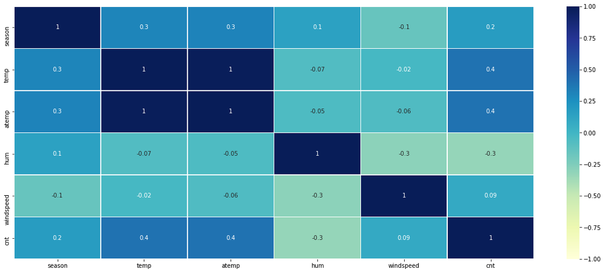

```python
# Configurando o tamanho da area do grafico
plt.figure(figsize=(20, 8))

# Selecionando apenas algumas colunas para verificar a correlação
corr = train[['season', 'temp', 'atemp', 'hum', 'windspeed', 'cnt']].corr()

# Configurar o heatmap
sns.heatmap(corr, linewidths=.5, vmin=-1, vmax=1, annot=True, cmap="YlGnBu", fmt='.1g')

# Imprimir o grafico
plt.show();
```

## Verificando outliers com boxplot

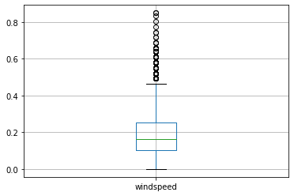

```python
# identificando possíveis outliers
train[['windspeed']].boxplot();
```

## Transformando variavel 'season' em categorica

```python
# Transformando a feature season
train['season'] = train['season'].astype('category')

# Verificando todas as categorias (no caso são 4)
train['season'].dtypes
```

```
CategoricalDtype(categories=[1.0, 2.0, 3.0, 4.0], ordered=False)
```

## Verificando dados estatísticos da feature 'windspeed'

```python
# Verificando dados estatisticos somente da variavel 'windspeed'
train['windspeed'].describe()
```

```
count    14082.000000
mean         0.189552
std          0.122309
min          0.000000
25%          0.104500
50%          0.164200
75%          0.253700
max          0.850700
Name: windspeed, dtype: float64
```